# Healthcare Cost Prediction Using Regression Models

Medical Health Insurance Cost Prediction with python using Different Regression Models.

## Overview

In response to the rising healthcare costs that strain budgets and reduce affordability, this project seeks to develop a predictive model for estimating individual healthcare expenses. By leveraging regression models, we aim to provide insights into the key factors that drive treatment costs, using patient demographics and medical information such as age, BMI, and smoking status. The objective is to create a model that enables healthcare providers to make data-driven decisions, optimize budget allocations, and ultimately achieve cost savings.

This project employs a range of regression techniques to evaluate and predict healthcare expenses, including multiple linear regression, Lasso, Ridge, ElasticNet, Random Forest, and Polynomial Regression. Each model is assessed for its accuracy and relevance to cost prediction, with the goal of delivering actionable insights that can help improve budget allocation by up to 20%, while also highlighting the impact of lifestyle and demographic factors on healthcare costs.

## Project Description

This project aims to predict healthcare costs for individuals based on factors such as age, BMI, smoking status, and other key demographic attributes. The goal is to create an effective model that can estimate healthcare expenses, enabling providers to optimize budget allocations and address rising healthcare costs.

This approach provides actionable insights for cost management, potentially leading to a 20% improvement in budget allocation and cost savings.

## Dataset Description

The dataset used for this project contains information on individual characteristics and their corresponding healthcare costs. Each row in the dataset represents an individual, with various attributes that are commonly relevant to healthcare costs. These attributes include:

1. **Age:** The age of the individual.
2. **Sex:** The gender of the individual, represented as male or female.
3. **BMI:** Body Mass Index, a measure of body fat based on height and weight.
4. **Children:** The number of children or dependents covered by the insurance policy.
5. **Smoker:** Indicates whether the individual is a smoker (yes or no).
6. **Region:** The region of the individual’s residence within the United States (e.g., northeast, southeast, northwest, southwest).
7. **Charges:** The total medical insurance cost for the individual, which serves as the target variable for prediction. The dataset provides a comprehensive view of key factors that may influence healthcare costs. By examining these attributes, we can gain insights into how variables such as age, BMI, smoking status, and region correlate with medical expenses, helping to build effective predictive models.

```python
# !pip install sklearn
# !pip install scikit-learn
```

```python
import pandas as pd
import numpy as np
```

```python
import matplotlib.pyplot as plt
%matplotlib inline
import seaborn as sns

import plotly.express as px
import plotly.graph_objects as go
import plotly.figure_factory as ff
from plotly.offline import download_plotlyjs, init_notebook_mode, iplot

import warnings
warnings.filterwarnings('ignore')
```

```python
# !pip install plotly
# !pip install plotly
```

```python
df = pd.read_csv('insurance.csv')
```

## Data Preprocessing

To prepare the dataset for modeling, we perform the following simple steps:

```python
df.head()
```

|  | age | sex | bmi | children | smoker | region | charges |
| --- | --- | --- | --- | --- | --- | --- | --- |
| 0 | 19 | female | 27.900 | 0 | yes | southwest | 16884.92400 |
| 1 | 18 | male | 33.770 | 1 | no | southeast | 1725.55230 |
| 2 | 28 | male | 33.000 | 3 | no | southeast | 4449.46200 |
| 3 | 33 | male | 22.705 | 0 | no | northwest | 21984.47061 |
| 4 | 32 | male | 28.880 | 0 | no | northwest | 3866.85520 |

```python
df.info()
```

```
<class 'pandas.core.frame.DataFrame'>
RangeIndex: 1338 entries, 0 to 1337
Data columns (total 7 columns):
 #   Column    Non-Null Count  Dtype
---  ------    --------------  -----
 0   age       1338 non-null   int64
 1   sex       1338 non-null   object
 2   bmi       1338 non-null   float64
 3   children  1338 non-null   int64
 4   smoker    1338 non-null   object
 5   region    1338 non-null   object
 6   charges   1338 non-null   float64
dtypes: float64(2), int64(2), object(3)
memory usage: 73.3+ KB
```

```python
df.describe
```

```
<bound method NDFrame.describe of       age     sex     bmi  children smoker     region      charges
0      19  female  27.900         0    yes  southwest  16884.92400
1      18    male  33.770         1     no  southeast   1725.55230
2      28    male  33.000         3     no  southeast   4449.46200
3      33    male  22.705         0     no  northwest  21984.47061
4      32    male  28.880         0     no  northwest   3866.85520
...   ...     ...     ...       ...    ...        ...          ...
1333   50    male  30.970         3     no  northwest  10600.54830
1334   18  female  31.920         0     no  northeast   2205.98080
1335   18  female  36.850         0     no  southeast   1629.83350
1336   21  female  25.800         0     no  southwest   2007.94500
1337   61  female  29.070         0    yes  northwest  29141.36030

[1338 rows x 7 columns]>
```

```python
df.describe()
```

|  | age | bmi | children | charges |
| --- | --- | --- | --- | --- |
| count | 1338.000000 | 1338.000000 | 1338.000000 | 1338.000000 |
| mean | 39.207025 | 30.663397 | 1.094918 | 13270.422265 |
| std | 14.049960 | 6.098187 | 1.205493 | 12110.011237 |
| min | 18.000000 | 15.960000 | 0.000000 | 1121.873900 |
| 25% | 27.000000 | 26.296250 | 0.000000 | 4740.287150 |
| 50% | 39.000000 | 30.400000 | 1.000000 | 9382.033000 |
| 75% | 51.000000 | 34.693750 | 2.000000 | 16639.912515 |
| max | 64.000000 | 53.130000 | 5.000000 | 63770.428010 |

```python
df.isnull().sum()
```

```
age         0
sex         0
bmi         0
children    0
smoker      0
region      0
charges     0
dtype: int64
```

There are no any null values

## Exploratory Data Analysis

Exploratory Data Analysis (EDA) helps us understand the data, identify patterns, and explore relationships between variables. In this project, we perform EDA to examine the factors affecting healthcare costs. Key steps include:

1. **Variable Distribution:** We analyze the distribution of key variables like age, BMI, and charges to understand how values are spread out across these features. For example, we look at histograms of charges to see the range of healthcare costs.
2. **Relationships Between Variables:** We explore relationships between variables, such as how age and smoker status impact charges. This can reveal important insights, like smokers generally incurring higher healthcare costs.
3. **Visualizations:** We use visualizations to make these patterns clearer: Histograms and Box Plots for understanding distributions and spotting outliers. Scatter Plots to see correlations (e.g., between BMI and charges). Heatmaps to examine correlations between all numerical variables, helping us see which factors are most associated with higher healthcare costs.

Using libraries like Seaborn, Matplotlib, and Plotly, we create these visuals to get a better understanding of the data and the factors that may drive healthcare expenses.

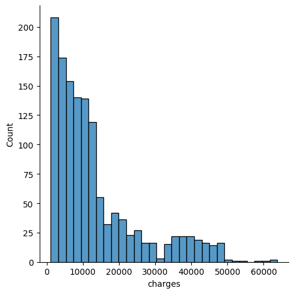

```python
#We can apply log transform to correct skewness
skewed = sns.displot(df['charges']) #Charges is right-skewed
skewed
```

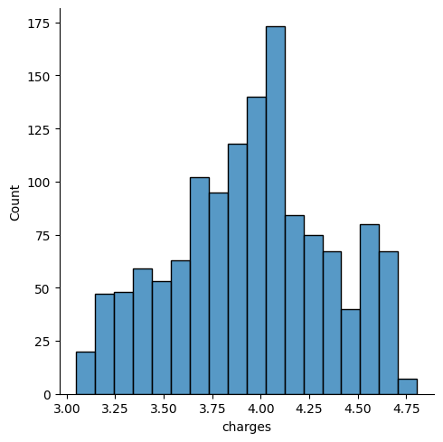

```python
log_trans = sns.displot(np.log10(df['charges'])) #skewness is corrected using log
log_trans
```

```python
#Charges by Region
charges = df['charges'].groupby(df['region']).sum().sort_values(ascending = True)
charges
```

```
region
southwest    4.012755e+06
northwest    4.035712e+06
northeast    4.343669e+06
southeast    5.363690e+06
Name: charges, dtype: float64
```

```python
# Ploting charges by region with plotly.express aka px
fig = px.bar(charges, title='Charges by Region', color=charges, color_continuous_scale='plasma')
fig.update_layout(
    margin=dict(t=50, b=0, l=0, r=0),
    titlefont=dict(size=20),
    xaxis_tickangle=-45,  # Specify the angle at which x-axis labels are displayed
)
fig.update_yaxes(showticklabels=False, title=' ')
fig.update_xaxes(title=' ')
fig.update_traces(
    texttemplate='%{y}',  # Display y values as text on the bars
    textposition='outside',  # Position the text outside the bars
    hovertemplate='<b>%{x}</b><br>Charges: %{y}',  # Customize hover template
)
fig.show()
```

[output not shown]

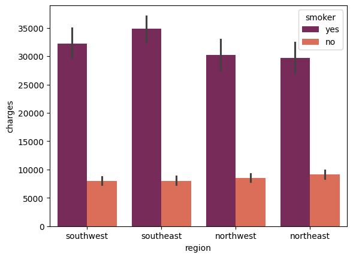

```python
#We check the charges by region who are smokers
sns.barplot(data = df, x = 'region', y = 'charges', hue = 'smoker', palette = 'rocket' )
```

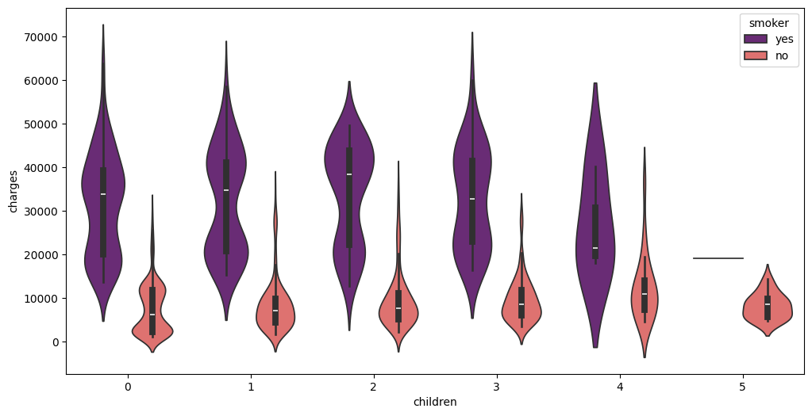

```python
plt.figure(figsize=(12,6))
sns.violinplot(data = df, x = 'children', y = 'charges', hue = 'smoker', split = False, palette = 'magma')
```

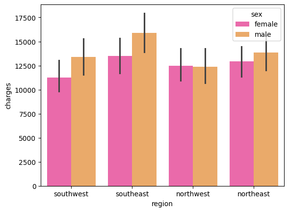

```python
#We check the charges by region by their gender
sns.barplot(data = df, x='region', y='charges', hue='sex', palette='spring')
```

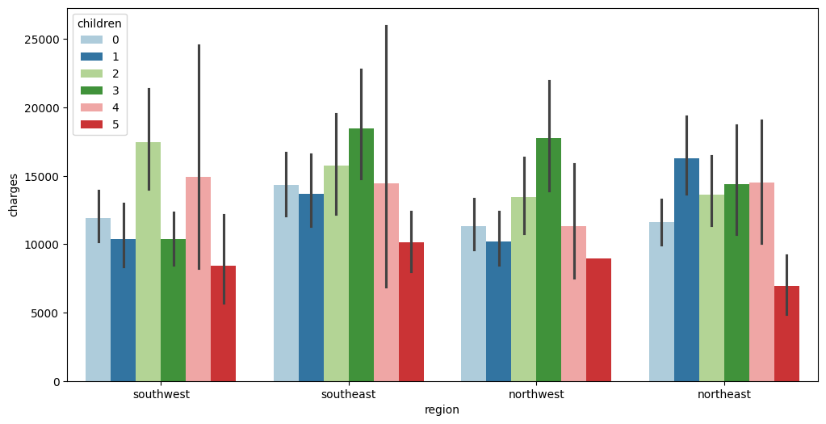

```python
#We check the charges by region by the children available
plt.figure(figsize=(12,6))
sns.barplot(data = df, x = 'region', y= 'charges',  hue = 'children', palette='Paired')
```

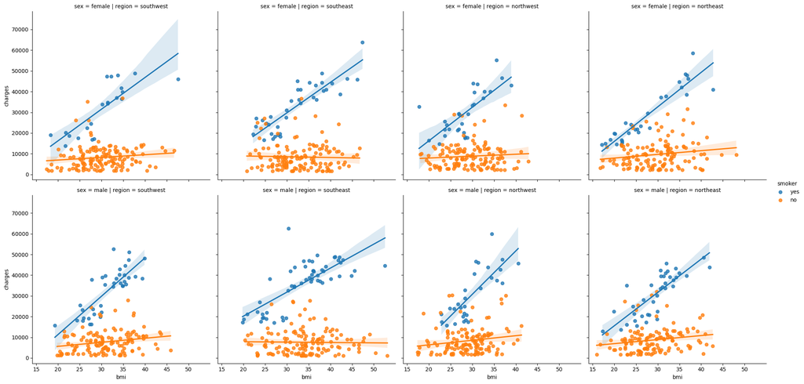

```python
#regression plot to understand the relationship between the bmi and charges considering
sns.lmplot(x = "bmi", y = "charges", row = "sex", col = "region", hue = 'smoker', data = df)
```

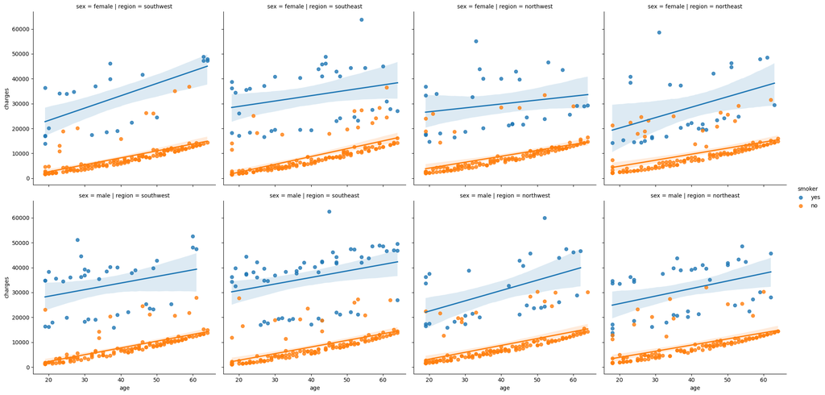

```python
#regression plot to understand the relationship between the Age and Charges considering
sns.lmplot(x = "age", y = "charges", row = "sex", col = "region", hue = 'smoker', data = df)
```

From the chart above we can see that those who are smokers get a higher medical insurance charges than those that are none smoker

```python
# Convert object labels to categorical data type
df[['sex', 'region', 'smoker']] = df[['sex', 'region', 'smoker']].astype('category')

# Check the updated data types
print(df.dtypes)
```

```
age            int64
sex         category
bmi          float64
children       int64
smoker      category
region      category
charges      float64
dtype: object
```

```python
# Converting category labels into numerical using LabelEncoder
from sklearn import preprocessing
label = preprocessing.LabelEncoder()

label.fit(df.sex.drop_duplicates())
df.sex = label.transform(df.sex)

label.fit(df.smoker.drop_duplicates())
df.smoker = label.transform(df.smoker)

label.fit(df.region.drop_duplicates())
df.region = label.transform(df.region)
```

```python
df.head()
```

|  | age | sex | bmi | children | smoker | region | charges |
| --- | --- | --- | --- | --- | --- | --- | --- |
| 0 | 19 | 0 | 27.900 | 0 | 1 | 3 | 16884.92400 |
| 1 | 18 | 1 | 33.770 | 1 | 0 | 2 | 1725.55230 |
| 2 | 28 | 1 | 33.000 | 3 | 0 | 2 | 4449.46200 |
| 3 | 33 | 1 | 22.705 | 0 | 0 | 1 | 21984.47061 |
| 4 | 32 | 1 | 28.880 | 0 | 0 | 1 | 3866.85520 |

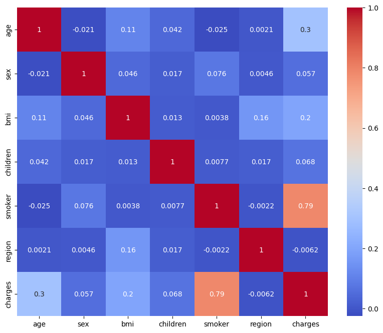

```python
plt.figure(figsize=(10,8))
sns.heatmap(df.corr(),cmap='coolwarm',annot=True)
```

```python
#we split our model
x = df.drop(['charges'], axis = 1)
y = df['charges']
```

```python
from sklearn.model_selection import train_test_split
x_train,x_test,y_train,y_test = train_test_split(x, y, test_size = 0.2, random_state = 42)
```

```python
# !pip install statsmodels

import statsmodels.api as sm #WE GET THE STATISTICAL MODEL
#add constant to predictor variables
x2 = sm.add_constant(x_train)
#fit linear regression model
model = sm.OLS(y_train, x2).fit()
```

```python
model.summary()
```

OLS Regression Results

| Dep. Variable: | charges | R-squared: | 0.742 |
| --- | --- | --- | --- |
| Model: | OLS | Adj. R-squared: | 0.740 |
| Method: | Least Squares | F-statistic: | 508.7 |
| Date: | Fri, 08 Nov 2024 | Prob (F-statistic): | 2.71e-308 |
| Time: | 06:32:13 | Log-Likelihood: | -10845. |
| No. Observations: | 1070 | AIC: | 2.170e+04 |
| Df Residuals: | 1063 | BIC: | 2.174e+04 |
| Df Model: | 6 |  |  |
| Covariance Type: | nonrobust |  |  |

|  | coef | std err | t | P>\|t\| | [0.025 | 0.975] |
| --- | --- | --- | --- | --- | --- | --- |
| const | -1.195e+04 | 1086.938 | -10.991 | 0.000 | -1.41e+04 | -9813.820 |
| age | 257.0563 | 13.452 | 19.109 | 0.000 | 230.661 | 283.451 |
| sex | -18.7915 | 375.770 | -0.050 | 0.960 | -756.126 | 718.543 |
| bmi | 335.7815 | 31.655 | 10.607 | 0.000 | 273.668 | 397.895 |
| children | 425.0915 | 154.431 | 2.753 | 0.006 | 122.067 | 728.116 |
| smoker | 2.365e+04 | 465.245 | 50.829 | 0.000 | 2.27e+04 | 2.46e+04 |
| region | -271.2843 | 170.373 | -1.592 | 0.112 | -605.590 | 63.022 |

| Omnibus: | 251.823 | Durbin-Watson: | 2.085 |
| --- | --- | --- | --- |
| Prob(Omnibus): | 0.000 | Jarque-Bera (JB): | 611.548 |
| Skew: | 1.251 | Prob(JB): | 1.60e-133 |
| Kurtosis: | 5.731 | Cond. No. | 299. |

Notes:  
[1] Standard Errors assume that the covariance matrix of the errors is correctly specified.

**Standard Errors:**

- [1] Standard Errors assume that the covariance matrix of the errors is correctly specified.

- Overall F-statistic for the regression model.

- p-value associated with the overall F-statistic.
- Determines if the regression model is statistically significant.
- p-value < 0.05 indicates a significant association of predictor variables with the response variable.

**coef:**

- Coefficients for each predictor variable.
- Represents average expected change in the response variable, with other predictors constant.

**P>|t|:**

- Individual p-values for each predictor variable.
- Indicates statistical significance.
- Statistically significant at α < 0.05, not significant at α >= 0.05.
- Example: "sex" not statistically significant, may be removed from the model.

## Regression Models

Multiple regression models are implemented to predict insurance costs.

## Multiple Linear Regression Model

```python
from sklearn.linear_model import LinearRegression
lm = LinearRegression()
```

```python
lm.fit(x_train,y_train)
```

```
LinearRegression()
```

```python
print('Intercept', lm.intercept_)
print('Coefficient', lm.coef_)
print('Score', lm.score(x_test, y_test))
```

```
Intercept -11946.606567263034
Coefficient [ 2.57056264e+02 -1.87914567e+01  3.35781491e+02  4.25091456e+02
  2.36478181e+04 -2.71284266e+02]
Score 0.7833463107364539
```

```python
coeff_df = pd.DataFrame(lm.coef_,x.columns,columns=['Coefficient'])
coeff_df
```

|  | Coefficient |
| --- | --- |
| age | 257.056264 |
| sex | -18.791457 |
| bmi | 335.781491 |
| children | 425.091456 |
| smoker | 23647.818096 |
| region | -271.284266 |

```python
#We Predict Our Model
y_pred1 = lm.predict(x_test)
```

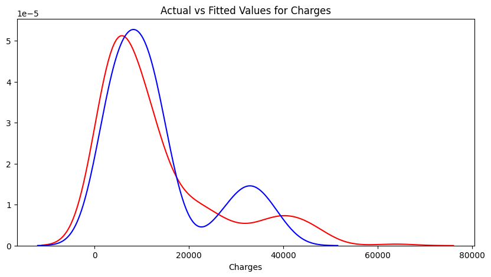

```python
plt.figure(figsize=(10, 5))
ax1 = sns.distplot(y_test, hist=False, color="r", label="Actual Value")
sns.distplot(y_pred1, hist=False, color="b", label="Fitted Values" , ax=ax1)
plt.title('Actual vs Fitted Values for Charges')
plt.xlabel('Charges')
plt.ylabel('')
plt.show()
plt.close()
```

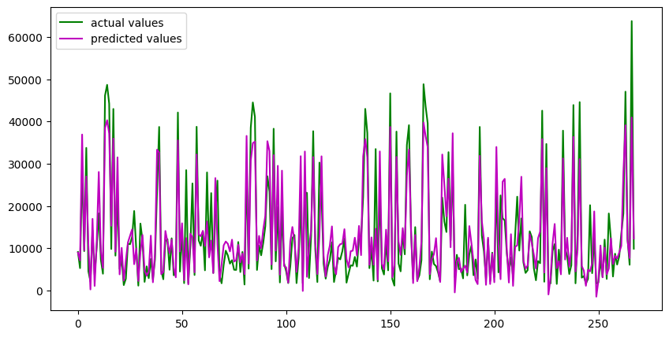

```python
## Another Plotting Technique
plt.figure(figsize=(10, 5))
# acutal values
plt.plot([i for i in range(len(y_test))],np.array(y_test), c='g', label="actual values")
# predicted values
plt.plot([i for i in range(len(y_test))],y_pred1, c='m',label="predicted values")
plt.legend()
plt.show()
```

```python
#Dataframe For Actual and Predicted Value
predicted1 = pd.DataFrame({'Actual': y_test, 'Predicted': y_pred1})
predicted1.head()
```

|  | Actual | Predicted |
| --- | --- | --- |
| 764 | 9095.06825 | 8924.407244 |
| 887 | 5272.17580 | 7116.295018 |
| 890 | 29330.98315 | 36909.013521 |
| 1293 | 9301.89355 | 9507.874691 |
| 259 | 33750.29180 | 27013.350008 |

## Lasso Regression Model

```python
from sklearn.linear_model import LassoCV
from sklearn.model_selection import RepeatedKFold
```

```python
#define cross-validation method to evaluate model
cv = RepeatedKFold(n_splits=10, n_repeats=4, random_state=101) #we’ll use the RepeatedKF
#define model
lasso_model = LassoCV(alphas=(0.1, 1.0, 10.0), cv=cv, n_jobs=-1)
#fit model
lasso_model.fit(x_train, y_train)
```

```
LassoCV(alphas=(0.1, 1.0, 10.0),
        cv=RepeatedKFold(n_repeats=4, n_splits=10, random_state=101),
        n_jobs=-1)
```

```python
print('Intercept', lm.intercept_)
print('Coefficient', lm.coef_)
print('Score', lm.score(x_test, y_test))
```

```
Intercept -11946.606567263034
Coefficient [ 2.57056264e+02 -1.87914567e+01  3.35781491e+02  4.25091456e+02
  2.36478181e+04 -2.71284266e+02]
Score 0.7833463107364539
```

```python
#We Predict Our Lassocv Regression Model
y_pred2 = lasso_model.predict(x_test)
```

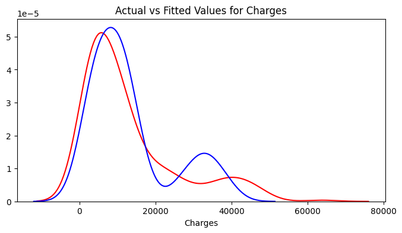

```python
# Visualising the Lasso Regression results
plt.figure(figsize=(8, 4))
ax1 = sns.distplot(y_test, hist=False, color="r", label="Actual Value")
sns.distplot(y_pred2, hist=False, color="b", label="Fitted Values" , ax=ax1)
plt.title('Actual vs Fitted Values for Charges')
plt.xlabel('Charges')
plt.ylabel('')
plt.show()
plt.close()
```

```python
#Dataframe For Actual and Predicted Value
predicted2 = pd.DataFrame({'Actual': y_test, 'Predicted': y_pred2})
predicted2.head()
```

|  | Actual | Predicted |
| --- | --- | --- |
| 764 | 9095.06825 | 8911.659191 |
| 887 | 5272.17580 | 7123.036794 |
| 890 | 29330.98315 | 36852.479165 |
| 1293 | 9301.89355 | 9515.428284 |
| 259 | 33750.29180 | 26976.771303 |

## Ridge Regression Model

```python
from sklearn.linear_model import Ridge
from sklearn.linear_model import RidgeCV
from sklearn.model_selection import RepeatedKFold
```

```python
#define cross-validation method to evaluate model
# cv = RepeatedKFold(n_splits=10, n_repeats=3, random_state=101)

#define model
rid_model = RidgeCV(alphas=(0.1,  1.0,  10.0), cv=cv, scoring='neg_mean_absolute_error')
#fit model
rid_model.fit(x_train, y_train)
```

```
RidgeCV(cv=RepeatedKFold(n_repeats=4, n_splits=10, random_state=101),
        scoring='neg_mean_absolute_error')
```

```python
print(rid_model.intercept_)
print(rid_model.coef_)
print(rid_model.score(x_test, y_test))
```

```
-11943.455858669682
[ 2.57035723e+02 -1.80109296e+01  3.35782790e+02  4.25136864e+02
  2.36341868e+04 -2.71303705e+02]
0.7833217621706015
```

```python
#We Predict Our Ridgecv Regression Model
y_pred3 = rid_model.predict(x_test)
```

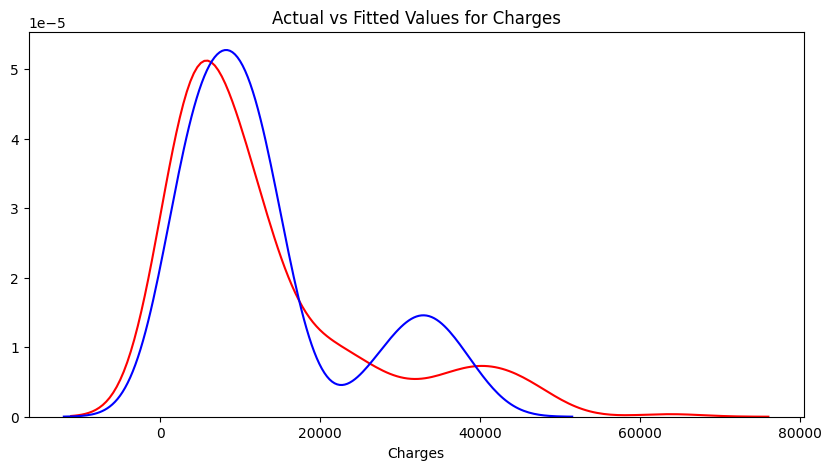

```python
# Visualising the Ridge Regression results
plt.figure(figsize=(10, 5))
ax1 = sns.distplot(y_test, hist=False, color="r", label="Actual Value")
sns.distplot(y_pred3, hist=False, color="b", label="Fitted Values" , ax=ax1)
plt.title('Actual vs Fitted Values for Charges')
plt.xlabel('Charges')
plt.ylabel('')
plt.show()
plt.close()
```

```python
#Dataframe For Actual and Predicted Value
predicted3 = pd.DataFrame({'Actual': y_test, 'Predicted': y_pred3})
predicted3.head()
```

|  | Actual | Predicted |
| --- | --- | --- |
| 764 | 9095.06825 | 8926.757144 |
| 887 | 5272.17580 | 7118.725826 |
| 890 | 29330.98315 | 36897.233767 |
| 1293 | 9301.89355 | 9511.011287 |
| 259 | 33750.29180 | 27003.281662 |

## Elasticnet Regressor

```python
from sklearn.model_selection import cross_val_score
from sklearn.model_selection import RepeatedKFold
from sklearn.linear_model import ElasticNet
```

```python
#define cross-validation method to evaluate model
cv = RepeatedKFold(n_splits=10, n_repeats=3, random_state=1)

# define model
net_model = ElasticNet(alpha=0.1, l1_ratio=0.9, fit_intercept=True, max_iter=1000, random_state=1)

# evaluate model
scores = cross_val_score(net_model, x_train,y_train, scoring='neg_mean_absolute_error', cv=cv)

net_model.fit(x_train, y_train)
```

```
ElasticNet(alpha=0.1, l1_ratio=0.9, random_state=1)
```

```python
print(net_model.intercept_)
print(net_model.coef_)
print(net_model.score(x_test, y_test))
```

```
-11626.875213341189
[  254.98398073    56.64093616   335.90294961   429.44085068
 22273.01597223  -273.05052278]
0.7789260673175409
```

```python
y_pred4 = net_model.predict(x_test)
```

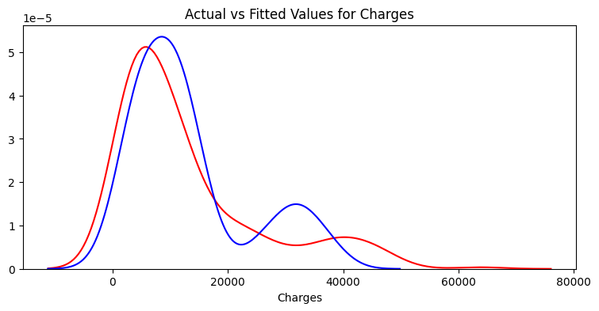

```python
# Visualising the ElasticNet Regressor results
plt.figure(figsize=(9, 4))
ax1 = sns.distplot(y_test, hist=False, color="r", label="Actual Value")
sns.distplot(y_pred4, hist=False, color="b", label="Fitted Values" , ax=ax1)
plt.title('Actual vs Fitted Values for Charges')
plt.xlabel('Charges')
plt.ylabel('')
plt.show()
plt.close()
```

```python
#Dataframe For Actual and Predicted Value
predicted4 = pd.DataFrame({'Actual': y_test, 'Predicted': y_pred4})
predicted4.head()
```

|  | Actual | Predicted |
| --- | --- | --- |
| 764 | 9095.06825 | 9162.642377 |
| 887 | 5272.17580 | 7363.304117 |
| 890 | 29330.98315 | 35722.815803 |
| 1293 | 9301.89355 | 9822.122303 |
| 259 | 33750.29180 | 25996.448958 |

## Random Forest Regressor

```python
from sklearn.ensemble import RandomForestRegressor
```

```python
Ram_reg = RandomForestRegressor(n_estimators=100, criterion='squared_error', min_samples_split=2)
# fit the regressor model
Ram_reg.fit(x_train, y_train)
```

```
RandomForestRegressor()
```

```python
print(Ram_reg.score(x_test, y_test))
```

```
0.8671250575640409
```

```python
y_pred5 = Ram_reg.predict(x_test)
```

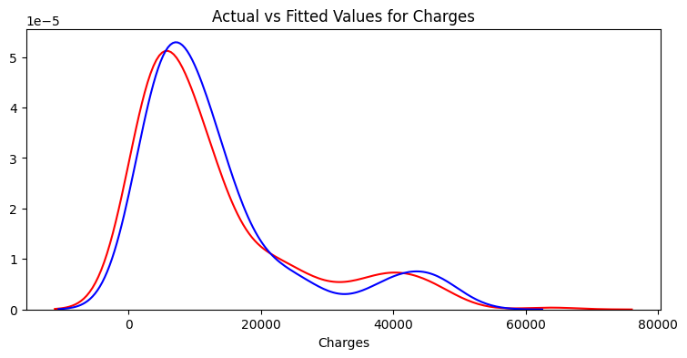

```python
# Visualising the Random Forest Regressor results
plt.figure(figsize=(9, 4))
ax1 = sns.distplot(y_test, hist=False, color="r", label="Actual Value")
sns.distplot(y_pred5, hist=False, color="b", label="Fitted Values" , ax=ax1)
plt.title('Actual vs Fitted Values for Charges')
plt.xlabel('Charges')
plt.ylabel('')
plt.show()
plt.close()
```

```python
#Dataframe For Actual and Predicted Value
predicted5 = pd.DataFrame({'Actual': y_test, 'Predicted': y_pred5})
predicted5.head()
```

|  | Actual | Predicted |
| --- | --- | --- |
| 764 | 9095.06825 | 10981.240708 |
| 887 | 5272.17580 | 5073.480958 |
| 890 | 29330.98315 | 28504.570914 |
| 1293 | 9301.89355 | 9911.496427 |
| 259 | 33750.29180 | 34638.550060 |

## We Try Select the Best Features Using Feature Importance from Random Forest Regressor

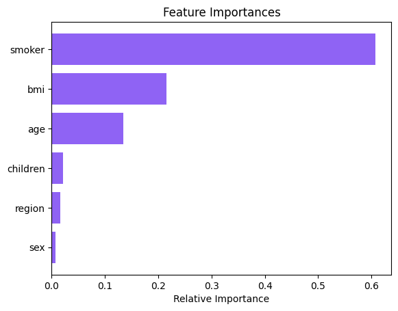

```python
features = x.columns
importances = Ram_reg.feature_importances_
indices = np.argsort(importances)

plt.title('Feature Importances')
plt.barh(range(len(indices)), importances[indices], color='#8f63f4', align='center')
plt.yticks(range(len(indices)), features[indices])
plt.xlabel('Relative Importance')
plt.show()
```

We can see that the smoker, bmi and age are more important features compared to the other features.

```python
#We select the import features
x = df.drop(['charges', 'region', 'sex'], axis = 1)
y = df['charges']
x_train, x_test, y_train, y_test = train_test_split(x, y, test_size = 0.2, random_state = 0)
```

```python
x
```

|  | age | bmi | children | smoker |
| --- | --- | --- | --- | --- |
| 0 | 19 | 27.900 | 0 | 1 |
| 1 | 18 | 33.770 | 1 | 0 |
| 2 | 28 | 33.000 | 3 | 0 |
| 3 | 33 | 22.705 | 0 | 0 |
| 4 | 32 | 28.880 | 0 | 0 |
| ... | ... | ... | ... | ... |
| 1333 | 50 | 30.970 | 3 | 0 |
| 1334 | 18 | 31.920 | 0 | 0 |
| 1335 | 18 | 36.850 | 0 | 0 |
| 1336 | 21 | 25.800 | 0 | 0 |
| 1337 | 61 | 29.070 | 0 | 1 |

1338 rows × 4 columns

#### WE BUILD A MODEL USING THE POLYNOMIAL REGRESSION AFTER FEATURE IMPORTANCE

## Polynomial Regression Model

```python
from sklearn.preprocessing import PolynomialFeatures

poly_reg = PolynomialFeatures(degree=2)

x_poly = poly_reg.fit_transform(x)

x_train,x_test,y_train,y_test = train_test_split(x_poly, y, test_size = 0.2, random_state = 0)
```

```python
pol_reg = LinearRegression()
pol_reg.fit(x_train, y_train)
```

```
LinearRegression()
```

```python
print(pol_reg.intercept_)
print(pol_reg.coef_)
print(pol_reg.score(x_test, y_test))
```

```
-5325.881705253518
[ 0.00000000e+00 -4.01606591e+01  5.23702019e+02  8.52025026e+02
 -9.52698471e+03  3.04430186e+00  1.84508369e+00  6.01720286e+00
  4.20849790e+00 -9.38983382e+00  3.81612289e+00  1.40840670e+03
 -1.45982790e+02 -4.46151855e+02 -9.52698471e+03]
0.8812595703345231
```

```python
#We Predict Our Polynomial Regression Model
y_pred6 = pol_reg.predict(x_test)
```

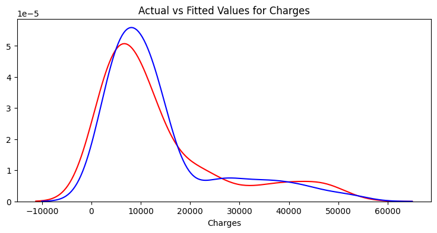

```python
# Visualising the Polynomial Regression results
plt.figure(figsize=(9, 4))
ax1 = sns.distplot(y_test, hist=False, color="r", label="Actual Value")
sns.distplot(y_pred6, hist=False, color="b", label="Fitted Values" , ax=ax1)
plt.title('Actual vs Fitted Values for Charges')
plt.xlabel('Charges')
plt.ylabel('')

plt.show()
plt.close()
```

## Model Evaluation

The performance of each regression model is evaluated using various metrics, including Mean Absolute Error (MAE), Mean Squared Error (MSE), and Root Mean Squared Error (RMSE). The evaluation results provide insights into the accuracy of the models in predicting insurance costs.

```python
from sklearn import metrics
from sklearn.metrics import r2_score
```

## Multiple Linear Regression

```python
print('Mean Absolute Error:', metrics.mean_absolute_error(y_test, y_pred1))
print('Mean Square Error:', metrics.mean_squared_error(y_test, y_pred1))
print('Root Mean Square Error:', np.sqrt(metrics.mean_squared_error(y_test, y_pred1)))
```

```
Mean Absolute Error: 10976.93032415958
Mean Square Error: 225340349.96269003
Root Mean Square Error: 15011.340711698273
```

## Lassocv Regression

```python
print('Mean Absolute Error:', metrics.mean_absolute_error(y_test, y_pred2))
print('Mean Square Error:', metrics.mean_squared_error(y_test, y_pred2))
print('Root Mean Square Error:', np.sqrt(metrics.mean_squared_error(y_test, y_pred2)))
```

```
Mean Absolute Error: 10968.76909663481
Mean Square Error: 224915279.38457984
Root Mean Square Error: 14997.17571359954
```

## Ridgecv Regression

```python
print('Mean Absolute Error:', metrics.mean_absolute_error(y_test, y_pred3))
print('Mean Square Error:', metrics.mean_squared_error(y_test, y_pred3))
print('Root Mean Square Error:', np.sqrt(metrics.mean_squared_error(y_test, y_pred3)))
```

```
Mean Absolute Error: 10975.462165520714
Mean Square Error: 225254498.69396153
Root Mean Square Error: 15008.480892280922
```

## Elasticnet Regression

```python
print('Mean Absolute Error:', metrics.mean_absolute_error(y_test, y_pred4))
print('Mean Square Error:', metrics.mean_squared_error(y_test, y_pred4))
print('Root Mean Square Error:', np.sqrt(metrics.mean_squared_error(y_test, y_pred4)))
```

```
Mean Absolute Error: 10838.727060068726
Mean Square Error: 216982294.5125357
Root Mean Square Error: 14730.31888699412
```

## Random Forest Regressor

```python
print('Mean Absolute Error:', metrics.mean_absolute_error(y_test, y_pred5))
print('Mean Square Error:', metrics.mean_squared_error(y_test, y_pred5))
print('Root Mean Square Error:', np.sqrt(metrics.mean_squared_error(y_test, y_pred5)))
```

```
Mean Absolute Error: 11507.85252687155
Mean Square Error: 267273802.87161243
Root Mean Square Error: 16348.510723353746
```

## Polynomial Regression

```python
print('Mean Absolute Error:', metrics.mean_absolute_error(y_test, y_pred6))
print('Mean Square Error:', metrics.mean_squared_error(y_test, y_pred6))
print('Root Mean Square Error:', np.sqrt(metrics.mean_squared_error(y_test, y_pred6)))
```

```
Mean Absolute Error: 2824.4950454776445
Mean Square Error: 18895160.09878035
Root Mean Square Error: 4346.856346692441
```

## Suggestions

1. **Promote Healthy Lifestyles:** Encourage smoking cessation programs and awareness campaigns to reduce the number of smokers. This could lead to substantial savings in healthcare costs.
2. **Health Awareness:** Run campaigns to educate people about the impact of BMI on health and insurance costs. Promoting healthy eating and exercise can help individuals maintain a healthy weight and potentially lower their medical expenses.
3. **Targeted Insurance Plans:** Design insurance plans that cater to different age groups. Tailored plans can address the unique healthcare needs of people at various life stages.
4. **Model Refinement:** Continue refining and optimizing predictive models. This could involve exploring more advanced algorithms or techniques to improve the accuracy of predictions.
5. **Regular Data Updates:** Regularly update the dataset with new data to ensure that the models remain relevant and accurate. Healthcare trends and cost patterns may change over time.
6. **Personalized Recommendations:** Provide personalized recommendations to individuals based on their age, smoking status, and BMI to help them make informed decisions about their healthcare and insurance choices.
7. **Collaboration with Healthcare Providers:** Collaborate with healthcare providers to gather more comprehensive data that includes detailed medical history. This could further enhance the accuracy of predictive models.
8. **Continuous Monitoring:** Keep monitoring the performance of predictive models and update them as necessary. New insights or changes in the healthcare landscape could require adjustments to the models.
9. **Customer Education:** Educate customers about how their lifestyle choices and age can impact their insurance costs. This transparency can help them make healthier decisions and potentially reduce their expenses.

By implementing these insights and suggestions, the insurance industry can make informed decisions to optimize insurance plans and promote healthier lifestyles among their customers.